# Teste Não-Paramétrico de Wilcoxon no R (trabalhando com dados em painel)

Geralmente, esse tipo de dado é bem representado pela “média”, no entanto a mediana é uma medida de tendência central que representa muito melhor, consequentemente o desvio padrão não tende a representar de forma adequada esses dados, dando assim preferência à amplitude interquartil.

**O que vamos executar?**  
* Fazer o teste de Kruskall-Wallis para mais de duas amostras independentes;  
* Fazer o post-hoc adequado ao teste de Kruskall-Wallis;  
* Pedir a estatística descritiva dos dados.

**Pressupostos:**  
* Variável dependente numérica ou ordinal;  
* Variável independente formada por grupos independentes.

**OBS:** Testes não-paramétricos, também conhecidos como testes de distribuição gratuita, são aqueles baseados em certas hipóteses, mas que não possuem uma organização normal. Geralmente, contêm resultados estatísticos provenientes de suas ordenações, o que os torna mais fáceis de entender.

# 1 Situação problema

O `Banco de Dados 5.csv` contém informações de 31 indivíduos tratados com placebo, um anti-hipertensivo já em uso no mercado ou um anti-hipertensivo novo. Verificar se há efeito do tratamento sobre a pressão sistólica e os batimentos cardíacos desses indivíduos. Descrever os resultados de forma apropriada.

# 2 Efetuando o Teste

Seguiremos alguns passos importantes a fim de reportar nossa análise.

## 2.1 Passo 1: Carregar os pacotes de dados.

```r
if(!require(dplyr)) install.packages("dplyr")
library(dplyr)
if(!require(rstatix)) install.packages("rstatix")
library(rstatix)
if(!require(ggplot2)) install.packages("ggplot2")
library(ggplot2)
```

## 2.2 Passo 2: Carregar o banco de dados.

Detalhe importante: selecionar o diretório de trabalho via *Session/Set Working Directory/Choose Directory*.

```r
dados <- read.csv('Banco de Dados 5.csv', sep = ';', dec = ',')
glimpse(dados)
```

```
## Rows: 31
## Columns: 6
## $ Sujeito       <int> 21, 30, 27, 20, 31, 28, 24, 18, 23, 22, 17, 19, 4, 25, 5~
## $ Grupo         <chr> "Placebo", "Placebo", "Placebo", "Placebo", "Placebo", "~
## $ Pressao       <dbl> 175.33, 158.00, 163.67, 184.67, 171.67, 192.67, 229.33, ~
## $ BC            <dbl> 356.33, 378.00, 397.33, 435.33, 365.33, 376.67, 459.33, ~
## $ Triglicerides <dbl> 65.84, 148.15, 115.23, 76.54, 73.25, 85.60, 67.49, 15.51~
## $ Glicemia      <int> 93, 109, 112, 113, 115, 116, 117, 128, 128, 129, 132, 13~
```

```r
library(rmarkdown)
paged_table(dados)
```

| Sujeito | Grupo | Pressao | BC | Triglicerides | Glicemia |
| --- | --- | --- | --- | --- | --- |
| 21 | Placebo | 175.33 | 356.33 | 65.84 | 93 |
| 30 | Placebo | 158.00 | 378.00 | 148.15 | 109 |
| 27 | Placebo | 163.67 | 397.33 | 115.23 | 112 |
| 20 | Placebo | 184.67 | 435.33 | 76.54 | 113 |
| 31 | Placebo | 171.67 | 365.33 | 73.25 | 115 |
| 28 | Placebo | 192.67 | 376.67 | 85.60 | 116 |
| 24 | Placebo | 229.33 | 459.33 | 67.49 | 117 |
| 18 | Placebo | 206.00 | 378.00 | 15.51 | 128 |
| 23 | Placebo | 188.00 | 384.33 | 122.63 | 128 |
| 22 | Placebo | 171.33 | 387.67 | 75.72 | 129 |

[output cut: 21 more lines]

## 2.3 Passo 3: Realização do teste de *Kruskall-Wallis*.

Primeiro precisamos identificar qual é a nossa variável dependente, e nesse caso gostaríamos de comparar os três grupos, quanto aos batimentos cardíacos (BC) e pressão arterial (Pressao).

- Placebo (Grupo A),
- Anti-hipertensivo Novo (Grupo B), e
- Anti-hipertensivo Padrão (Grupo C).

```r
kruskal.test(BC ~ Grupo, data = dados)
```

```
##
##  Kruskal-Wallis rank sum test
##
## data:  BC by Grupo
## Kruskal-Wallis chi-squared = 17.135, df = 2, p-value = 0.0001902
```

```r
kruskal.test(Pressao ~ Grupo, data = dados)
```

```
##
##  Kruskal-Wallis rank sum test
##
## data:  Pressao by Grupo
## Kruskal-Wallis chi-squared = 8.9028, df = 2, p-value = 0.01166
```

Quando falamos desse teste em específico, estamos pensando na distribuição dos dados, porque o teste faz um ranqueamento dos valores e faz a análise estatística a partir desses postos. Portanto, a hipótese é que esses grupos apresentam distribuições diferentes. Se os grupos tiverem o mesmo formato de distribuição dos dados, estaremos comparando as medianas, mas se os formatos forem diferentes, então a comparação é de distribuição (porque apresentaria medianas diferentes). Então, as hipóteses nulas se referem às medianas.

Assim, teremos:

- H<sub>0</sub>: Mediana do Grupo A = Mediana do Grupo B = Mediana do Grupo C = normal → p > 0,05
- H<sub>1</sub>: Mediana do Grupo A ≠ Mediana do Grupo B ≠ Mediana do Grupo C ≠ normal → p ≤ 0,05

Considerando que para os batimentos cardíacos (BC) temos *p-value = 0.0001902 ≤ 0,05*, e para a pressão arterial (Pressao), o *p-value = 0.01166 ≤ 0,05*, rejeitando a hipótese nula H<sub>0</sub> e aceitando a hipótese alternativa H<sub>1</sub> para ambos os casos, o que quer dizer que existe pelo menos uma diferença entre as medianas dos grupos Placebo, Anti-Hipertensivo Novo e Anti-Hipertensivo Padrão.

O teste mostra que existe diferença, mas não diz que diferença seria essa, então nesse caso precisamos fazer um teste de *Post-Hoc*.

## 2.4 Passo 4: Testes de Post-Hoc

Efetuamos *Teste de Dunn* com ajuste do *p-value*:

```r
dunn_test(BC ~ Grupo, data = dados, p.adjust.method = "bonferroni")
```

```
## # A tibble: 3 x 9
##   .y.   group1    group2       n1    n2 statistic         p    p.adj p.adj.sig~1
## * <chr> <chr>     <chr>     <int> <int>     <dbl>     <dbl>    <dbl> <chr>
## 1 BC    AH Novo   AH Padrão     9    10    -0.827 0.408     1        ns
## 2 BC    AH Novo   Placebo       9    12     2.94  0.00330   0.00991  **
## 3 BC    AH Padrão Placebo      10    12     3.91  0.0000910 0.000273 ***
## # ... with abbreviated variable name 1: p.adj.signif
```

```r
dunn_test(Pressao ~ Grupo, data = dados, p.adjust.method = "bonferroni")
```

```
## # A tibble: 3 x 9
##   .y.     group1    group2       n1    n2 statistic       p   p.adj p.adj.signif
## * <chr>   <chr>     <chr>     <int> <int>     <dbl>   <dbl>   <dbl> <chr>
## 1 Pressao AH Novo   AH Padrão     9    10     -1.19 0.235   0.706   ns
## 2 Pressao AH Novo   Placebo       9    12      1.64 0.101   0.304   ns
## 3 Pressao AH Padrão Placebo      10    12      2.96 0.00307 0.00921 **
```

Agora para pressão arteria (Pressao), vemos diferença significativa apenas entre os grupos que tomaram AH Padrão e o Placebo, onde verificamos *p-value ≤ 0.05*.

## 2.5 Passo 5: Análise descritiva dos dados

```r
dados %>% group_by(Grupo) %>%
  get_summary_stats(BC, Pressao, type = "median_iqr")
```

```
## # A tibble: 6 x 5
##   Grupo     variable     n median   iqr
##   <chr>     <fct>    <dbl>  <dbl> <dbl>
## 1 AH Novo   BC           9   352   16.3
## 2 AH Novo   Pressao      9   171.  11
## 3 AH Padrão BC          10   333.  39.9
## 4 AH Padrão Pressao     10   158.  13.4
## 5 Placebo   BC          12   378   25.3
## 6 Placebo   Pressao     12   183.  21.2
```

## 2.6 Passo 6: Visualização dos Dados

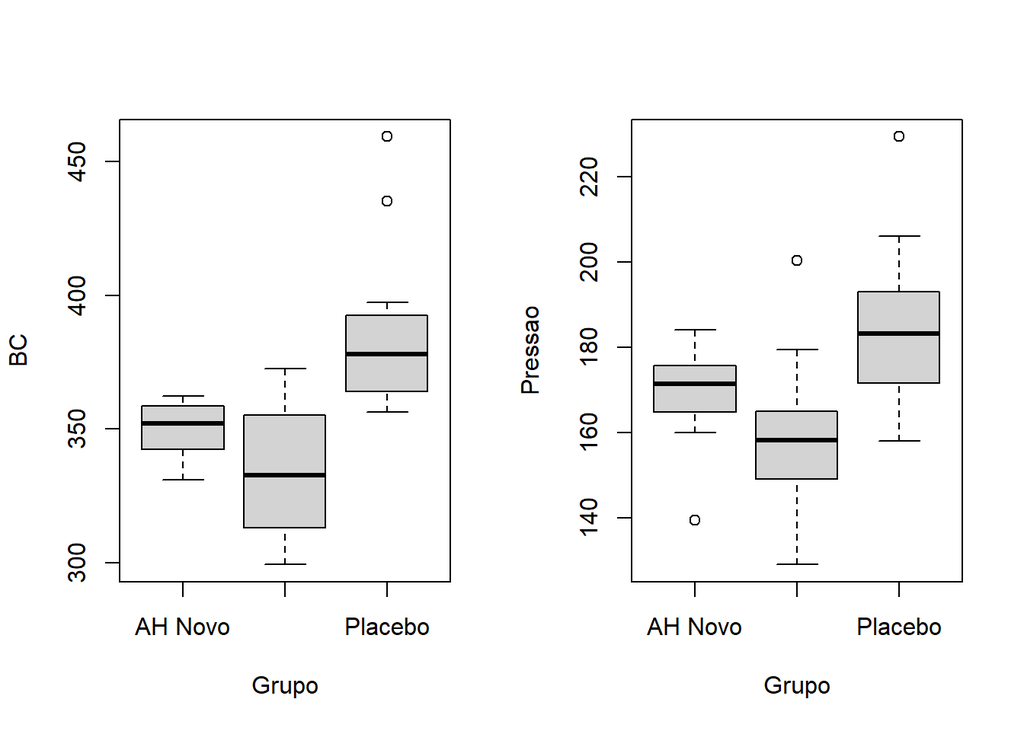

```r
par(mfrow=c(1,2))
boxplot(BC ~ Grupo, data=dados)
boxplot(Pressao ~ Grupo, data=dados)
```

## 2.7 Passo 7: Distribuição dos Dados

### 2.7.1 Diferença por Batimentos Cardíacos (BC):

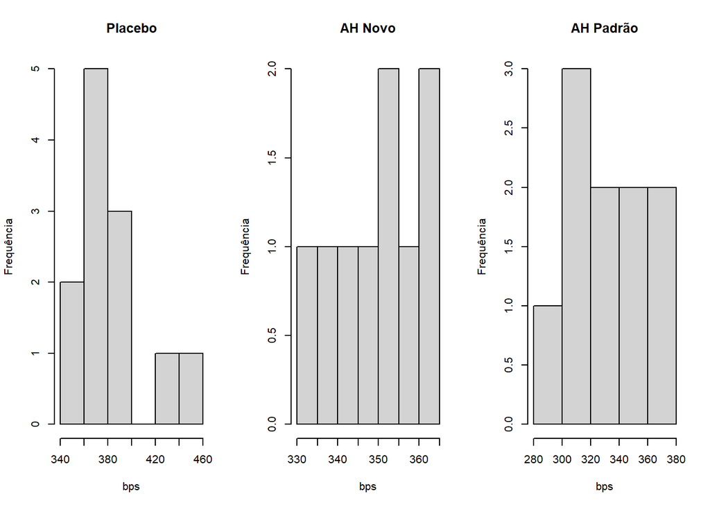

```r
par(mfrow=c(1,3))
hist(dados$BC[dados$Grupo == "Placebo"],
     ylab = "Frequência", xlab = "bps", main="Placebo")
hist(dados$BC[dados$Grupo == "AH Novo"],
     ylab = "Frequência", xlab = "bps", main="AH Novo")
hist(dados$BC[dados$Grupo == "AH Padrão"],
     ylab = "Frequência", xlab = "bps", main="AH Padrão")
```

### 2.7.2 Diferença por Pressão Arterial (Pressao):

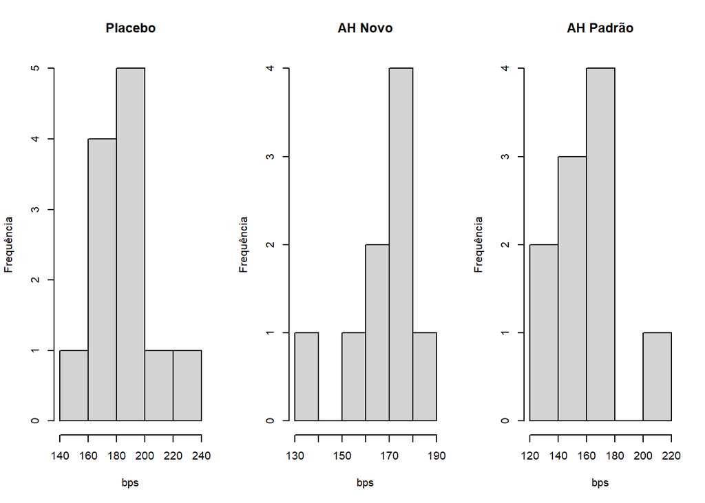

```r
par(mfrow=c(1,3))
hist(dados$Pressao[dados$Grupo == "Placebo"],
     ylab = "Frequência", xlab = "bps", main="Placebo")
hist(dados$Pressao[dados$Grupo == "AH Novo"],
     ylab = "Frequência", xlab = "bps", main="AH Novo")
hist(dados$Pressao[dados$Grupo == "AH Padrão"],
     ylab = "Frequência", xlab = "bps", main="AH Padrão")
```

## 2.8 Histograma com todos os grupos, separados por cor

### 2.8.1 Diferença por Batimentos Cardíacos (BC):

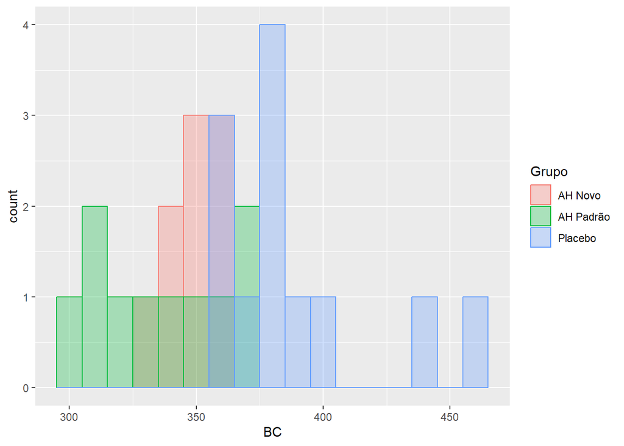

```r
ggplot(dados, aes(x = BC)) +
  geom_histogram(aes(color = Grupo, fill = Grupo),
                 alpha = 0.3, position = "identity", binwidth = 10)
```

### 2.8.2 Diferença por Pressão Arterial (Pressao):

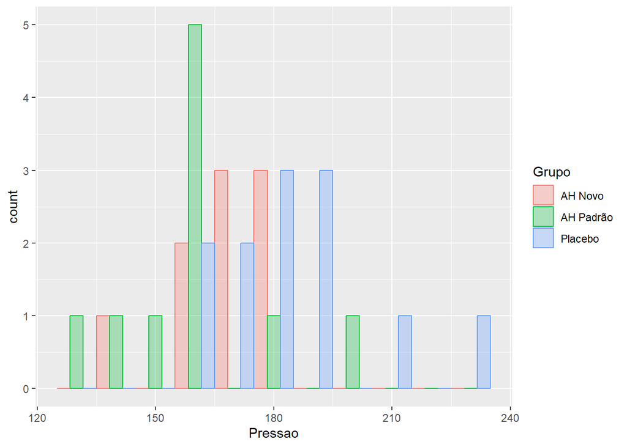

```r
ggplot(dados, aes(x = Pressao)) +
  geom_histogram(aes(color = Grupo, fill = Grupo),
                 alpha = 0.3, position = "dodge", binwidth = 10)
```

# 3 Resultado

Para as diferenças nos Batimentos Cardíacos (BC), o *Teste de Kruskall-Wallis* mostrou que há diferença entre os grupos (X<sup>2</sup><sub>(2)</sub> = 17,14; p < 0.05). O *post-hoc de Dunn* mostrou que o grupo “Placebo” (378 e 25,3, mediana e amplitude interquartil) é diferente dos grupos “AH Novo” (352 e 16,3) e “AH Padrão” (333 e 39,9).